# CIND 123 - Data Analytics: Basic Methods

## Q3c (8 points)

Construct two boxplots for the `Ozone` and `Solar.R` variables. Then, compute the values of all outliers which lie beyond the whiskers.

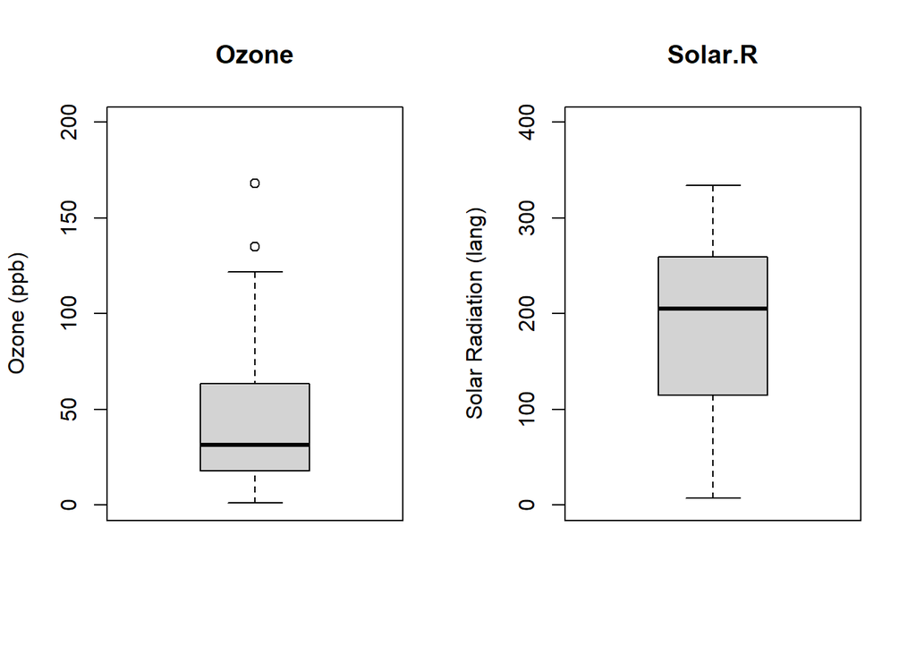

```r
## Loading the dataset
data(airquality)

## Constructing boxplots for Ozone and Solar.R variables
par(mfrow=c(1,2))
boxplot(airquality$Ozone, main="Ozone", ylab="Ozone (ppb)", ylim=c(0, 200))
boxplot(airquality$Solar.R, main="Solar.R", ylab="Solar Radiation (lang)", ylim=c(0, 400))
```

```r
## Computing outliers for Ozone
ozone <- airquality$Ozone
ozone_outliers <- boxplot.stats(ozone)$out

## Computing outliers for Solar.R
solar <- airquality$Solar.R
solar_outliers <- boxplot.stats(solar)$out

## Printing the outliers
cat("Outliers for Ozone: ", ozone_outliers, "\n")
```

```
## Outliers for Ozone:  135 168
```

```r
cat("Outliers for Solar.R: ", solar_outliers, "\n")
```

```
## Outliers for Solar.R:
```

## Q3d (8 points)

HINT: Only show the lower quartile using indexing. For the type of quartile, please see https://www.rdocumentation.org/packages/stats/versions/3.6.2/topics/quantile.

```r
## Loading the airquality dataset
data(airquality)

## Computing the lower quartile of Temp using quantile function
lower_quartile_quantile <- quantile(airquality$Temp, probs = 0.25)

## Printing the lower quartile
print(lower_quartile_quantile)
```

```
## 25%
##  72
```

## Q3e (8 points)

Construct a bar chart to describe the number of entries by `Month`.

HINT: use the `table()` function to count and tabulate the number of entries within a `Month`.

Don’t forget to name each axis and have a title for the plot.

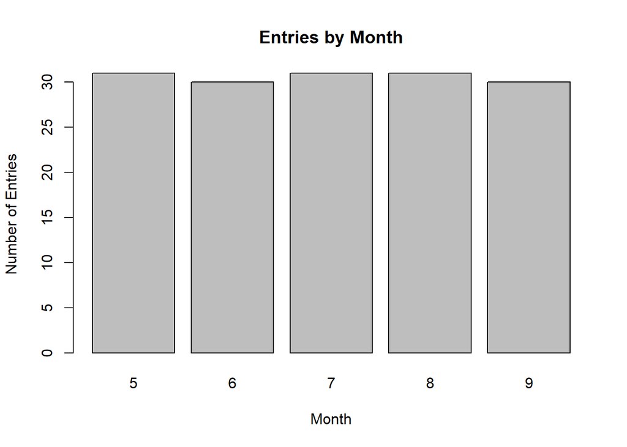

```r
## Loading the dataset
data(airquality)

## Creating a bar chart of entries by month
barplot(table(airquality$Month),
        main = "Entries by Month",
        xlab = "Month",
        ylab = "Number of Entries",)
```

END of Assignment #1.